# Functions

AG Schissler (modified from Ryan Tibshirani)

Monday September 17, 2018

## I. Opening

### Start-of-class work

1. Log in the your workstation.
2. Open the RStudio application on your machine.
3. Open functions.Rmd from website so that you can work along the lecture.

### Why do we need functions?

- Data structures tie related values into one object
- Functions tie related commands into one object
- In both cases: easier to understand, easier to work with, easier to build into larger things

**Remember those commands you typed over and over?**

### Today learning outcomes

Students will be able to - use and write R functions.

## II. Function basics

From our lectures on text manipulation and regexes:

```r
# Get Trump's word counts
trump_lines <- readLines("http://www.stat.cmu.edu/~ryantibs/statcomp/data/trump.txt")
trump_text <- paste(trump_lines, collapse=" ")
trump_words <- strsplit(trump_text, split="[[:space:]]|[[:punct:]]")[[1]]
trump_words <- trump_words[trump_words != ""]
trump_wordtab <- table(trump_words)

# Now do the same for Clinton's speech, etc., etc.
```

### Creating your own function

Call `function()` to create your own function. Document your function with comments

```r
# get_wordtab_from_url: get a word table from text on the web
# Input:
# - str_url: string, specifying URL of a web page
# Output: word table, i.e., vector with counts as entries and associated
#   words as names

get_wordtab_from_url <- function(str_url) {
  lines <- readLines(str_url)
  text <- paste(lines, collapse=" ")
  words <- strsplit(text, split="[[:space:]]|[[:punct:]]")[[1]]
  words <- words[words != ""]
  wordtab <- table(words)
  return(wordtab)
}
```

### Function structure

The structure of a function has three basic parts:

- **Inputs** (or **arguments**)
- **Body** (code that is executed)
- **Output** (or **return value**)

R doesn’t let your function have multiple outputs, but you can return a list

### Using your created function

Our created functions can be used just like the built-in ones

```r
# Using our function
trump_wordtab_new = get_wordtab_from_url(
  "http://www.stat.cmu.edu/~ryantibs/statcomp/data/trump.txt")
all(trump_wordtab_new == trump_wordtab)
```

```
## [1] TRUE
```

```r
## YOU DO: choose another website to see result

# Revealing our function's definition
get_wordtab_from_url
```

```
## function(str_url) {
##   lines <- readLines(str_url)
##   text <- paste(lines, collapse=" ")
##   words <- strsplit(text, split="[[:space:]]|[[:punct:]]")[[1]]
##   words <- words[words != ""]
##   wordtab <- table(words)
##   return(wordtab)
## }
```

### Returning more than one thing

When creating a function in R, though you cannot return more than one output, you can **return a list**. This (by definition) can contain an arbitrary number of arbitrary objects

```r
# get_wordtab_from_url: get a word table from text on the web
# Inputs:
# - str_url: string, specifying URL of a web page
# - split: string, specifying what to split on. Default is the regex pattern
#   "[[:space:]]|[[:punct:]]"
# - tolower: Boolean, TRUE if words should be converted to lower case before
#   the word table is computed. Default is TRUE
# - keep_nums: Boolean, TRUE if words containing numbers should be kept in the
#   word table. Default is FALSE
# Output: list, containing word table, and then some basic numeric summaries

get_wordtab_from_url = function(str_url, split="[[:space:]]|[[:punct:]]",
                                tolower=TRUE, keep_nums=FALSE) {
  lines = readLines(str_url)
  text = paste(lines, collapse=" ")
  words = strsplit(text, split=split)[[1]]
  words = words[words != ""]

  # Convert to lower case, if we're asked to
  if (tolower) words = tolower(words)

  # Get rid of words with numbers, if we're asked to
  if (!keep_nums)
    words = grep("[0-9]", words, inv=TRUE, val=TRUE)

  # Compute the word table
  wordtab = table(words)

  return(list(wordtab=wordtab,
              number_unique_words=length(wordtab),
              number_total_words=sum(wordtab),
              longest_word=words[which.max(nchar(words))]))
}
```

```r
# Trump's Republican National Convention speech
trump_wordtab = get_wordtab_from_url(
  "http://www.stat.cmu.edu/~ryantibs/statcomp/data/trump.txt")
lapply(trump_wordtab, head)
```

```
## $wordtab
## words
##         a   abandon abandoned      able   abolish     about
##        54         1         1         2         1         4
##
## $number_unique_words
## [1] 1236
##
## $number_total_words
## [1] 4431
##
## $longest_word
## [1] "straightforward"
```

```r
### YOU TRY: Try on your own url
```

### Side effects

A **side effect** of a function is something that happens as a result of the function’s body, but is not returned. Examples:

- Printing something out to the console
- Plotting something on the display
- Saving an R data file, or a PDF, etc.

```r
# get_wordtab_from_url: get a word table from text on the web
# Inputs:
# - str_url: string, specifying URL of a web page
# - split: string, specifying what to split on. Default is the regex pattern
#   "[[:space:]]|[[:punct:]]"
# - tolower: Boolean, TRUE if words should be converted to lower case before
#   the word table is computed. Default is TRUE
# - keep_nums: Boolean, TRUE if words containing numbers should be kept in the
#   word table. Default is FALSE
# - hist: Boolean, TRUE if a histogram of word lengths should be plotted as a
#   side effect. Default is FALSE
# Output: list, containing word table, and then some basic numeric summaries

get_wordtab_from_url = function(str_url, split="[[:space:]]|[[:punct:]]",
                                tolower=TRUE, keep_nums=FALSE, hist=FALSE) {
  lines = readLines(str_url)
  text = paste(lines, collapse=" ")
  words = strsplit(text, split=split)[[1]]
  words = words[words != ""]

  # Convert to lower case, if we're asked to
  if (tolower) words = tolower(words)

  # Get rid of words with numbers, if we're asked to
  if (!keep_nums)
    words = grep("[0-9]", words, inv=TRUE, val=TRUE)

  # Plot the histogram of the word lengths, if we're asked to
  if (hist)
    hist(nchar(words), col="lightblue", breaks=0:max(nchar(words)),
         xlab="Word length")

  # Compute the word table
  wordtab = table(words)

  return(list(wordtab=wordtab,
              number_unique_words=length(wordtab),
              number_total_words=sum(wordtab),
              longest_word=words[which.max(nchar(words))]))
}
```

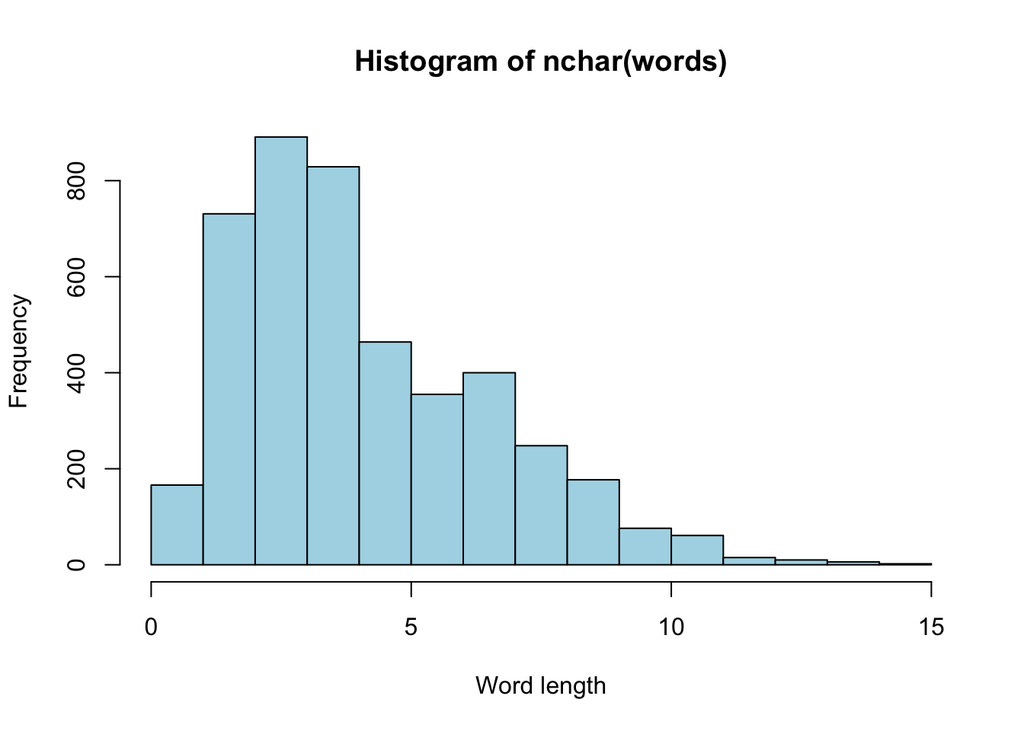

```r
# Trump's speech
trump_wordtab = get_wordtab_from_url(
  str_url="http://www.stat.cmu.edu/~ryantibs/statcomp/data/trump.txt",
  hist=TRUE)
```

```r
lapply(trump_wordtab, head)
```

```
## $wordtab
## words
##         a   abandon abandoned      able   abolish     about
##        54         1         1         2         1         4
##
## $number_unique_words
## [1] 1236
##
## $number_total_words
## [1] 4431
##
## $longest_word
## [1] "straightforward"
```

```r
### YOU TRY: Try on your own url
```

### II. Guided practice: Huber loss function

The notation below defines the Huber loss function (or just Huber function, for short), with cutoff $a$:
$$\psi_a(x) = \begin{cases}
x^2 & \text{if $|x| \leq a$} \\
2a|x| - a^2 & \text{if $|x| > a$}
\end{cases}$$
This function is quadratic on the interval $[-a,a]$, and linear outside of this interval. It transitions from quadratic to linear “smoothly”.

### Practice writing a function

```r
## WE DO: Write a function for huber loss
huber <- function(x, a=1) {
    ## OUR CODE HERE
}
```

### Plotting practice, side effects

- Using `huber()`, create a plot of the Huber function that you see above (with $a=1$).

```r
## YOUR CODE HERE
```

- Modify the `huber()` function so that, as a side effect, it prints the string “Invented by the great Swiss statistician Peter Huber!” to the console. Hint: use `cat()`. Call your function on an input of your choosing, to demonstrate this side effect.

```r
## YOUR CODE HERE
```

## III. Top-down function design

1. Start with the big-picture view of the task
2. Break the task into a few big parts
3. Figure out how to fit the parts together
4. Repeat this for each part

### Start off with a code sketch

You can write top-level code, right away, for your function’s design:

```
# Not actual code
big_job = function(lots_of_arguments) {
  first_result = first_step(some_of_the_args)
  second_result = second_step(first_result, more_of_the_args)
  final_result = third_step(second_result, rest_of_the_args)
  return(final_result)
}
```

After you write down your design, go ahead and write the sub-functions (here `first_step()`, `second_step()`, `third_step()`). The process may be iterative, in that you may write these sub-functions, then go back and change the design a bit, etc.

With practice, this design strategy should become natural.

#### IV. Summary: 3-2-1

- List/describe 3 revelant R built-in functions you used today
- Give 2 reasons why to write functions.
- Share the most interesting thing for you today.